# DƏRS 2: Esse Yazılarının Strukturu və Növləri

Müxtəlif esse növlərinin xüsusiyyətləri və qiymətləndirmə kriteriyaları

Azərbaycan Respublikası Təhsil Nazirliyi - Peşəkar İnkişaf Mərkəzi

2025-08-01

### 🎯 DƏRSİN ÖYRƏNMƏ MƏQSƏDLƏRİ

Bu dərsin sonunda siz aşağıdakıları bacara biləcəksiniz:

- **Esse növləri:** Müxtəlif esse tiplərini tanımaq və xüsusiyyətlərini bilmək
- **Struktur analizi:** Esse strukturunun komponentlərini dərin anlamaq
- **Qiymətləndirmə rubrikləri:** Hər esse növü üçün uyğun rubrik yaratmaq
- **Praktik qiymətləndirmə:** Esse nümunələrini professional şəkildə qiymətləndirmək
- **R-də təhlil:** Esse qiymətlərini R-də analiz etmək və vizuallaşdırmaq

# 1 Essenin Tərifləri və Əsas Xarakteristikaları

Esse - şəxsi fikirlər, müşahidələr və təhlillərin yaradıcı şəkildə ifadə edildiği yazılı iş növüdür.

## 1.1 Essenin Əsas Elementləri

#### 📋 Klassik Esse Strukturu

- **Giriş (Introduction):** Mövzunu təqdim edən və tezisi ifadə edən hissə
- **Əsas hissə (Body):** Arqumentlərin və sübutların təqdim edildiği hissələr
- **Nəticə (Conclusion):** Əsas fikirləri ümumiləşdirən və nəticə çıxaran hissə

```r
# Esse struktur komponentlərinin təhlili
structure_components <- tibble(
  Component = c("Giriş", "Əsas Hissə", "Nəticə"),
  Typical_Length = c("10-15%", "70-80%", "10-15%"),
  Primary_Function = c("Maraq yaratmaq və tezis", "Sübutlar və təhlil", "Ümumiləşdirmə"),
  Key_Elements = c("Hook, Background, Thesis", "Topic sentences, Evidence, Analysis", "Restatement, Implications")
)

kable(structure_components,
      caption = "Esse Strukturunun Əsas Komponentləri",
      col.names = c("Komponent", "Tipik Uzunluq", "Əsas Funksiya", "Açar Elementlər")) %>%
  kable_styling(bootstrap_options = c("striped", "hover", "condensed", "responsive")) %>%
  column_spec(1, bold = TRUE, color = "white", background = "#667eea") %>%
  column_spec(2, bold = TRUE, color = "#27ae60") %>%
  column_spec(3, italic = TRUE)
```

Esse Strukturunun Əsas Komponentləri

| Komponent | Tipik Uzunluq | Əsas Funksiya | Açar Elementlər |
| --- | --- | --- | --- |
| Giriş | 10-15% | Maraq yaratmaq və tezis | Hook, Background, Thesis |
| Əsas Hissə | 70-80% | Sübutlar və təhlil | Topic sentences, Evidence, Analysis |
| Nəticə | 10-15% | Ümumiləşdirmə | Restatement, Implications |

```r
cat("📊 ESSE STRUKTURU TƏHLİLİ:\n")
```

```
#> 📊 ESSE STRUKTURU TƏHLİLİ:
```

```r
cat("========================\n")
cat("✅ Ümumi komponent sayı:", nrow(structure_components), "\n")
```

```
#> ✅ Ümumi komponent sayı: 3
```

```r
cat("🎯 Ən böyük hissə:", "Əsas Hissə (70-80%)", "\n")
```

```
#> 🎯 Ən böyük hissə: Əsas Hissə (70-80%)
```

```r
cat("📝 Strukturun balansı: Giriş və Nəticə hər biri təxminən 10-15%\n")
```

```
#> 📝 Strukturun balansı: Giriş və Nəticə hər biri təxminən 10-15%
```

# 2 Esse Növləri və Xüsusiyyətləri

## 2.1 1. Mühakimə Essesi (Argumentative Essay)

#### ⚔️ Mühakimə Essesi

**Məqsəd:** Müəyyən bir mövzu haqqında mövqe götürmək və onu arqumentlərlə müdafiə etmək

**Struktur xüsusiyyətləri:**

- Aydın tezis ifadəsi
- Güclü sübutlar və nümunələr
- Əks arqumentlərin nəzərə alınması
- Məntiqi ardıcıllıq

## 2.2 2. Təsviri Esse (Descriptive Essay)

#### 🎨 Təsviri Esse

**Məqsəd:** Bir şəxs, yer, əşya və ya hadisəni canlı şəkildə təsvir etmək

**Struktur xüsusiyyətləri:**

- Həssas detallar və görüntülər
- Beş hissə müraciət
- Emosional təsir
- Yaradıcı dil istifadəsi

## 2.3 3. İzahat Essesi (Expository Essay)

#### 📚 İzahat Essesi

**Məqsəd:** Mövzunu obyektiv şəkildə izah etmək və məlumat vermək

**Struktur xüsusiyyətləri:**

- Aydın və dəqiq məlumat
- Məntiqi təşkilat
- Faktlara əsaslanan məzmun
- Obyektiv ton

## 2.4 4. Hekayə Essesi (Narrative Essay)

#### 📖 Hekayə Essesi

**Məqsəd:** Şəxsi təcrübə və ya hekayə vasitəsilə dərs və ya məna çatdırmaq

**Struktur xüsusiyyətləri:**

- Xronoloji ardıcıllıq
- Xarakter inkişafı
- Dialoq istifadəsi
- Şəxsi refleksiya

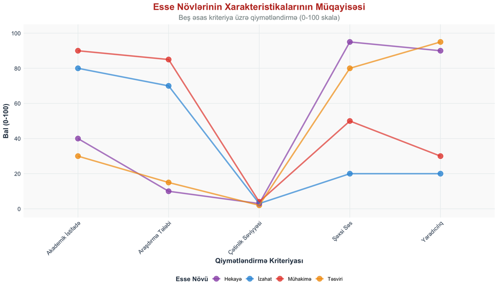

```r
# Esse növlərinin müqayisəli təhlili
essay_types_data <- tibble(
  Essay_Type = c("Mühakimə", "Təsviri", "İzahat", "Hekayə"),
  Difficulty_Level = c(4, 2, 3, 3),
  Academic_Usage = c(90, 30, 80, 40),
  Creative_Elements = c(30, 95, 20, 90),
  Research_Required = c(85, 15, 70, 10),
  Personal_Voice = c(50, 80, 20, 95)
)

# Radar chart üçün məlumatları hazırlamaq
essay_comparison_long <- essay_types_data %>%
  pivot_longer(cols = Difficulty_Level:Personal_Voice,
               names_to = "Criteria", values_to = "Score") %>%
  mutate(
    Criteria = case_when(
      Criteria == "Difficulty_Level" ~ "Çətinlik Səviyyəsi",
      Criteria == "Academic_Usage" ~ "Akademik İstifadə",
      Criteria == "Creative_Elements" ~ "Yaradıcılıq",
      Criteria == "Research_Required" ~ "Araşdırma Tələbi",
      Criteria == "Personal_Voice" ~ "Şəxsi Səs"
    )
  )

# Müqayisəli qrafik
essay_comparison_plot <- essay_comparison_long %>%
  ggplot(aes(x = Criteria, y = Score, color = Essay_Type, group = Essay_Type)) +
  geom_point(size = 4, alpha = 0.8) +
  geom_line(size = 1.2, alpha = 0.7) +
  scale_y_continuous(limits = c(0, 100), breaks = seq(0, 100, 20)) +
  scale_color_manual(values = c("Mühakimə" = "#e74c3c", "Təsviri" = "#f39c12",
                               "İzahat" = "#3498db", "Hekayə" = "#9b59b6")) +
  labs(
    title = "Esse Növlərinin Xarakteristikalarının Müqayisəsi",
    subtitle = "Beş əsas kriteriya üzrə qiymətləndirmə (0-100 skala)",
    x = "Qiymətləndirmə Kriteriyası",
    y = "Bal (0-100)",
    color = "Esse Növü"
  ) +
  theme_essay_education() +
  theme(
    axis.text.x = element_text(angle = 45, hjust = 1),
    legend.position = "bottom"
  )

print(essay_comparison_plot)
```

```r
# Statistik təhlil
cat("\n📊 ESSE NÖVLƏRİ STATİSTİK TƏHLİLİ:\n")
```

```
#>
#> 📊 ESSE NÖVLƏRİ STATİSTİK TƏHLİLİ:
```

```r
cat("================================\n")
for(essay_type in unique(essay_types_data$Essay_Type)) {
  type_data <- essay_types_data[essay_types_data$Essay_Type == essay_type, ]
  avg_score <- round(mean(c(type_data$Difficulty_Level, type_data$Academic_Usage,
                           type_data$Creative_Elements, type_data$Research_Required,
                           type_data$Personal_Voice)), 1)
  cat("📝", essay_type, "Essesi - Orta bal:", avg_score, "\n")
}
```

```
#> 📝 Mühakimə Essesi - Orta bal: 51.8
#> 📝 Təsviri Essesi - Orta bal: 44.4
#> 📝 İzahat Essesi - Orta bal: 38.6
#> 📝 Hekayə Essesi - Orta bal: 47.6
```

# 3 Esse Qiymətləndirmə Rubrikləri

## 3.1 Ümumi Qiymətləndirmə Rubrik Strukturu

#### 📊 Rubrik Əsas Sahələri

- **Məzmun və İdeyalar (25%):** Mövzunun dərk edilməsi, ideya inkişafı, yaradıcılıq
- **Təşkilat və Struktur (25%):** Məntiqi ardıcıllıq, keçidlər, ümumi strukturun aydınlığı
- **Dil və Üslub (25%):** Lüğət, cümlə strukturu, ton və səs
- **Konvensiyalar (25%):** Qrammatika, orfoqrafiya, durğu işarələri

```r
# Rubrik kriteriyalarının ətraflı təhlili
rubric_criteria <- tibble(
  Criteria = c("Məzmun və İdeyalar", "Təşkilat və Struktur", "Dil və Üslub", "Konvensiyalar"),
  Weight_Percentage = c(25, 25, 25, 25),
  Level_4_Excellent = c("Mövzu hərtərəfli araşdırılıb, orijinal fikirlər",
                        "Aydın struktur, effektiv keçidlər",
                        "Zəngin lüğət, müxtəlif cümlə strukturları",
                        "Səhvsiz qrammatika və orfoqrafiya"),
  Level_3_Good = c("Mövzu yaxşı anlaşılıb, əsasən relevant fikirlər",
                   "Ümumiyyətlə aydın struktur, bəzi keçid problemləri",
                   "Uyğun lüğət, əsasən düzgün cümlələr",
                   "Kiçik qrammatik səhvlər"),
  Level_2_Developing = c("Mövzu qismən anlaşılıb, bəzi kənara çıxmalar",
                         "Əsas struktur var, lakin bəzi qarışıqlıqlar",
                         "Məhdud lüğət, sadə cümlə strukturları",
                         "Çoxlu kiçik səhvlər"),
  Level_1_Beginning = c("Mövzu zəif anlaşılıb, relevant olmayan məzmun",
                        "Qarışıq struktur, aydın olmayan təşkilat",
                        "Çox məhdud lüğət, səhvli cümlələr",
                        "Çoxsaylı ciddi səhvlər")
)

# Rubrik cədvəlini göstərmək
kable(rubric_criteria %>% select(Criteria, Weight_Percentage, Level_4_Excellent, Level_1_Beginning),
      caption = "Esse Qiymətləndirmə Rubrik Kriteriyaları",
      col.names = c("Kriteriya", "Çəki (%)", "Səviyyə 4 (Əla)", "Səviyyə 1 (Başlanğıc)")) %>%
  kable_styling(bootstrap_options = c("striped", "hover", "condensed", "responsive")) %>%
  column_spec(1, bold = TRUE, color = "white", background = "#667eea") %>%
  column_spec(2, bold = TRUE, color = "#27ae60") %>%
  column_spec(3, background = "#d4edda") %>%
  column_spec(4, background = "#f8d7da")
```

Esse Qiymətləndirmə Rubrik Kriteriyaları

| Kriteriya | Çəki (%) | Səviyyə 4 (Əla) | Səviyyə 1 (Başlanğıc) |
| --- | --- | --- | --- |
| Məzmun və İdeyalar | 25 | Mövzu hərtərəfli araşdırılıb, orijinal fikirlər | Mövzu zəif anlaşılıb, relevant olmayan məzmun |
| Təşkilat və Struktur | 25 | Aydın struktur, effektiv keçidlər | Qarışıq struktur, aydın olmayan təşkilat |
| Dil və Üslub | 25 | Zəngin lüğət, müxtəlif cümlə strukturları | Çox məhdud lüğət, səhvli cümlələr |
| Konvensiyalar | 25 | Səhvsiz qrammatika və orfoqrafiya | Çoxsaylı ciddi səhvlər |

```r
cat("\n📋 RUBRİK TƏHLİL NƏTİCƏLƏRİ:\n")
```

```
#>
#> 📋 RUBRİK TƏHLİL NƏTİCƏLƏRİ:
```

```r
cat("========================\n")
cat("🎯 Ümumi kriteriya sayı:", nrow(rubric_criteria), "\n")
```

```
#> 🎯 Ümumi kriteriya sayı: 4
```

```r
cat("⚖️ Hər kriteriyanın çəkisi:", unique(rubric_criteria$Weight_Percentage), "%\n")
```

```
#> ⚖️ Hər kriteriyanın çəkisi: 25 %
```

```r
cat("📊 Qiymətləndirmə səviyyələri: 4 (Əla) - 1 (Başlanğıc)\n")
```

```
#> 📊 Qiymətləndirmə səviyyələri: 4 (Əla) - 1 (Başlanğıc)
```

```r
cat("💯 Maksimal bal: 100 (hər kriteriya üzrə 25)\n")
```

```
#> 💯 Maksimal bal: 100 (hər kriteriya üzrə 25)
```

## 3.2 Esse Növlərinə Görə Xüsusi Rubrik Kriteriyaları

#### 🎯 Mühakimə Essesi üçün Xüsusi Kriterialar

- **Tezis aydınlığı:** Əsas arqumentin dəqiq ifadə edilməsi
- **Sübutların gücü:** Etibarlı mənbələr və məqbul nümunələr
- **Əks arqumentlər:** Müخالif fikirlərin tanınması və cavablandırılması
- **Məntiqi əlaqələr:** Fikirlərin məntiqi ardıcıllıqla bağlanması

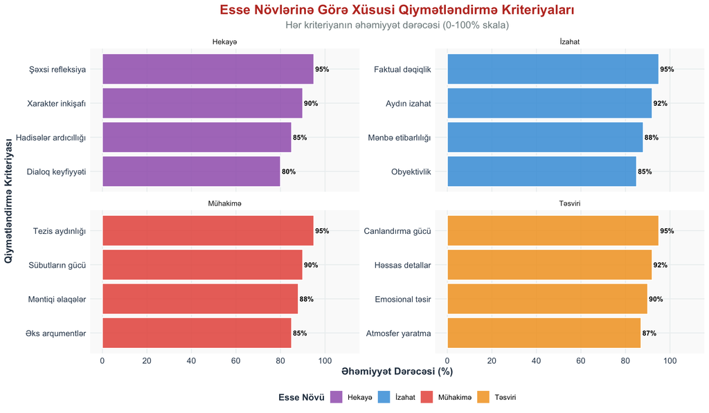

```r
# Hər esse növü üçün xüsusi rubrik kriteriyaları
specific_criteria <- tibble(
  Essay_Type = rep(c("Mühakimə", "Təsviri", "İzahat", "Hekayə"), each = 4),
  Specific_Criteria = c(
    # Mühakimə
    "Tezis aydınlığı", "Sübutların gücü", "Əks arqumentlər", "Məntiqi əlaqələr",
    # Təsviri
    "Həssas detallar", "Canlandırma gücü", "Atmosfer yaratma", "Emosional təsir",
    # İzahat
    "Faktual dəqiqlik", "Aydın izahat", "Mənbə etibarlılığı", "Obyektivlik",
    # Hekayə
    "Hadisələr ardıcıllığı", "Xarakter inkişafı", "Dialoq keyfiyyəti", "Şəxsi refleksiya"
  ),
  Importance_Score = c(
    # Mühakimə
    95, 90, 85, 88,
    # Təsviri
    92, 95, 87, 90,
    # İzahat
    95, 92, 88, 85,
    # Hekayə
    85, 90, 80, 95
  )
)

# Hər esse növü üçün kriteriyaların vizual təqdimatı
criteria_plot <- specific_criteria %>%
  ggplot(aes(x = reorder(Specific_Criteria, Importance_Score), y = Importance_Score, fill = Essay_Type)) +
  geom_col(alpha = 0.8, color = "white", size = 0.5) +
  geom_text(aes(label = paste0(Importance_Score, "%")),
            hjust = -0.1, fontface = "bold", size = 3) +
  scale_fill_manual(values = c("Mühakimə" = "#e74c3c", "Təsviri" = "#f39c12",
                              "İzahat" = "#3498db", "Hekayə" = "#9b59b6")) +
  scale_y_continuous(limits = c(0, 110), breaks = seq(0, 100, 20)) +
  coord_flip() +
  labs(
    title = "Esse Növlərinə Görə Xüsusi Qiymətləndirmə Kriteriyaları",
    subtitle = "Hər kriteriyanın əhəmiyyət dərəcəsi (0-100% skala)",
    x = "Qiymətləndirmə Kriteriyası",
    y = "Əhəmiyyət Dərəcəsi (%)",
    fill = "Esse Növü"
  ) +
  theme_essay_education() +
  theme(legend.position = "bottom") +
  facet_wrap(~Essay_Type, scales = "free_y", ncol = 2)

print(criteria_plot)
```

```r
# Esse növləri üzrə orta əhəmiyyət hesablamaq
cat("\n🎯 ESSE NÖVLƏRİNƏ GÖRƏ ORTA ƏHƏMİYYƏT:\n")
```

```
#>
#> 🎯 ESSE NÖVLƏRİNƏ GÖRƏ ORTA ƏHƏMİYYƏT:
```

```r
cat("=====================================\n")
specific_criteria %>%
 group_by(Essay_Type) %>%
 summarise(avg_importance = round(mean(Importance_Score), 1)) %>%
 arrange(desc(avg_importance)) %>%
 {
   for(i in 1:nrow(.)) {
     cat("📝", .$Essay_Type[i], ":", .$avg_importance[i], "% orta əhəmiyyət\n")
   }
 }
```

```
#> 📝 Təsviri : 91 % orta əhəmiyyət
#> 📝 İzahat : 90 % orta əhəmiyyət
#> 📝 Mühakimə : 89.5 % orta əhəmiyyət
#> 📝 Hekayə : 87.5 % orta əhəmiyyət
```

# 4 Praktik Esse Qiymətləndirmə Nümunələri

#### 📋 “Texnologiyanın təhsilə təsiri” mövzusunda mühakimə essesi

**Tələbə yaşı:** 11-ci sinif (16-17 yaş)

**Esse uzunluğu:** 350 söz

**Yazı müddəti:** 45 dəqiqə

```r
# Nümunə esse qiymətləndirmə məlumatları
sample_essays <- tibble(
  Essay_ID = paste0("E", 1:20),
  Essay_Type = sample(c("Mühakimə", "Təsviri", "İzahat", "Hekayə"), 20, replace = TRUE),
  Content_Ideas = round(runif(20, 60, 95), 1),
  Organization = round(runif(20, 65, 92), 1),
  Language_Style = round(runif(20, 62, 88), 1),
  Conventions = round(runif(20, 70, 96), 1),
  Grade_Level = sample(c("9-cu", "10-cu", "11-ci"), 20, replace = TRUE),
  Writing_Time = sample(c(30, 45, 60), 20, replace = TRUE)
) %>%
  mutate(
    Total_Score = round((Content_Ideas + Organization + Language_Style + Conventions) / 4, 1),
    Letter_Grade = case_when(
      Total_Score >= 90 ~ "A",
      Total_Score >= 80 ~ "B",
      Total_Score >= 70 ~ "C",
      Total_Score >= 60 ~ "D",
      TRUE ~ "F"
    )
  )

# Esse qiymətləndirmə nəticələrinin cədvəli
kable(sample_essays %>% select(Essay_ID, Essay_Type, Content_Ideas, Organization, Language_Style, Conventions, Total_Score, Letter_Grade) %>% head(10),
      caption = "Nümunə Esse Qiymətləndirmə Nəticələri",
      col.names = c("Esse ID", "Növü", "Məzmun", "Təşkilat", "Dil", "Konvensiya", "Ümumi", "Hərf Qiyməti")) %>%
  kable_styling(bootstrap_options = c("striped", "hover", "condensed", "responsive")) %>%
  column_spec(1, bold = TRUE, color = "white", background = "#667eea") %>%
  column_spec(7, bold = TRUE, color = ifelse(head(sample_essays$Total_Score, 10) >= 80, "#27ae60", "#e74c3c")) %>%
  column_spec(8, bold = TRUE)
```

Nümunə Esse Qiymətləndirmə Nəticələri

| Esse ID | Növü | Məzmun | Təşkilat | Dil | Konvensiya | Ümumi | Hərf Qiyməti |
| --- | --- | --- | --- | --- | --- | --- | --- |
| E1 | Təsviri | 68.7 | 76.6 | 72.2 | 79.6 | 74.3 | C |
| E2 | İzahat | 94.1 | 70.8 | 77.5 | 77.7 | 80.0 | B |
| E3 | Hekayə | 62.5 | 83.5 | 73.7 | 73.6 | 73.3 | C |
| E4 | İzahat | 60.1 | 67.6 | 62.1 | 91.9 | 70.4 | C |
| E5 | Hekayə | 66.2 | 88.2 | 68.8 | 77.8 | 75.2 | C |
| E6 | Təsviri | 64.0 | 84.8 | 74.8 | 94.5 | 79.5 | C |
| E7 | Hekayə | 66.0 | 74.9 | 66.3 | 70.9 | 69.5 | D |
| E8 | İzahat | 69.1 | 73.9 | 69.0 | 78.7 | 72.7 | C |
| E9 | İzahat | 85.6 | 80.8 | 84.9 | 94.9 | 86.6 | B |
| E10 | İzahat | 85.4 | 77.0 | 84.8 | 77.1 | 81.1 | B |

```r
# Qiymətləndirmə statistikaları
cat("\n📊 ESSE QİYMƏTLƏNDİRMƏ STATİSTİKALARI:\n")
```

```
#>
#> 📊 ESSE QİYMƏTLƏNDİRMƏ STATİSTİKALARI:
```

```r
cat("================================\n")
cat("👥 Qiymətləndirilen esse sayı:", nrow(sample_essays), "\n")
```

```
#> 👥 Qiymətləndirilen esse sayı: 20
```

```r
cat("📈 Orta ümumi bal:", round(mean(sample_essays$Total_Score), 1), "\n")
```

```
#> 📈 Orta ümumi bal: 77.1
```

```r
cat("🎯 Ən yüksək bal:", max(sample_essays$Total_Score), "\n")
```

```
#> 🎯 Ən yüksək bal: 86.6
```

```r
cat("⚠️ Ən aşağı bal:", min(sample_essays$Total_Score), "\n")
```

```
#> ⚠️ Ən aşağı bal: 69.5
```

```r
cat("📊 Keçid qiyməti (70+) alan esselər:", sum(sample_essays$Total_Score >= 70), "ədəd\n")
```

```
#> 📊 Keçid qiyməti (70+) alan esselər: 19 ədəd
```

## 4.2 Rubrik Əsaslı Qiymətləndirmə Prosesi

#### ⚙️ Addım-addım Qiymətləndirmə Prosesi

1. **İlkin oxu:** Ümumi məzmun və struktura baxış
2. **Kriteriya əsaslı təhlil:** Hər rubrik sahəsi üzrə dəqiq qiymətləndirmə
3. **Bal təyin etmə:** 1-4 skala üzrə hər kriteriya üçün bal vermə
4. **Ümumi qiymət:** Bütün sahələrin ortası və hərf qiyməti
5. **Konstruktiv şərh:** Güclü tərəflər və təkmilləşdirmə sahələri

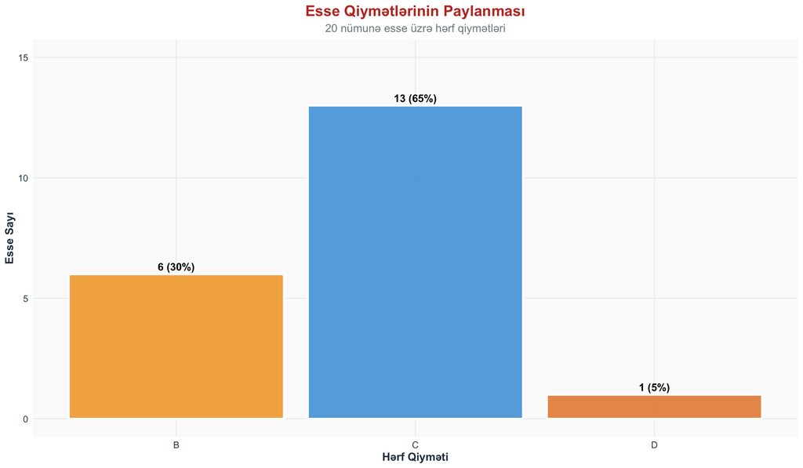

```r
# Qiymət paylanması təhlili
grade_distribution <- sample_essays %>%
  count(Letter_Grade) %>%
  mutate(
    Percentage = round(n / sum(n) * 100, 1),
    Letter_Grade = factor(Letter_Grade, levels = c("A", "B", "C", "D", "F"))
  )

# Qiymət paylanması qrafiki
grade_plot <- grade_distribution %>%
  ggplot(aes(x = Letter_Grade, y = n, fill = Letter_Grade)) +
  geom_col(alpha = 0.8, color = "white", size = 1) +
  geom_text(aes(label = paste0(n, " (", Percentage, "%)")),
            vjust = -0.5, fontface = "bold", size = 4) +
  scale_fill_manual(values = c("A" = "#27ae60", "B" = "#f39c12", "C" = "#3498db",
                               "D" = "#e67e22", "F" = "#e74c3c")) +
  scale_y_continuous(limits = c(0, max(grade_distribution$n) + 2)) +
  labs(
    title = "Esse Qiymətlərinin Paylanması",
    subtitle = "20 nümunə esse üzrə hərf qiymətləri",
    x = "Hərf Qiyməti",
    y = "Esse Sayı",
    fill = "Qiymət"
  ) +
  theme_essay_education() +
  theme(legend.position = "none")

print(grade_plot)
```

```r
# Esse növləri üzrə performans müqayisəsi
type_performance <- sample_essays %>%
  group_by(Essay_Type) %>%
  summarise(
    Count = n(),
    Avg_Score = round(mean(Total_Score), 1),
    Min_Score = min(Total_Score),
    Max_Score = max(Total_Score),
    .groups = 'drop'
  ) %>%
  arrange(desc(Avg_Score))

cat("\n🎯 ESSE NÖVLƏRİ ÜZRƏ PERFORMANS:\n")
```

```
#>
#> 🎯 ESSE NÖVLƏRİ ÜZRƏ PERFORMANS:
```

```r
cat("==============================\n")
for(i in 1:nrow(type_performance)) {
  cat("📝", type_performance$Essay_Type[i], ":\n")
  cat("   📊 Orta bal:", type_performance$Avg_Score[i], "\n")
  cat("   📈 Ən yüksək:", type_performance$Max_Score[i], "\n")
  cat("   📉 Ən aşağı:", type_performance$Min_Score[i], "\n")
  cat("   👥 Say:", type_performance$Count[i], "esse\n\n")
}
```

```
#> 📝 İzahat :
#>    📊 Orta bal: 80.2
#>    📈 Ən yüksək: 86.6
#>    📉 Ən aşağı: 70.4
#>    👥 Say: 8 esse
#>
#> 📝 Təsviri :
#>    📊 Orta bal: 76.3
#>    📈 Ən yüksək: 79.5
#>    📉 Ən aşağı: 73.4
#>    👥 Say: 4 esse
#>
#> 📝 Hekayə :
#>    📊 Orta bal: 74.5
#>    📈 Ən yüksək: 78.4
#>    📉 Ən aşağı: 69.5
#>    👥 Say: 6 esse
#>
#> 📝 Mühakimə :
#>    📊 Orta bal: 74
#>    📈 Ən yüksək: 74.1
#>    📉 Ən aşağı: 73.9
#>    👥 Say: 2 esse
```